# modMetricsR

Giulio Giagnoni

2023-08-25

# Before starting

Packages required and number notation.

```r
library(modMetricsR)
library(epiR)
library(ggplot2)
library(dplyr)
library(flextable)

options(scipen = 999) # normal notation for numbers
```

# Package overview

## Examples

Here examples of use for the functions included.

### opmetrics

With `opmetrics`, which stands for “observed-predicted-metrics”, this function can be run just by providing observed and predicted value from the model, as:

```r
m <- lm(Petal.Length ~ Sepal.Length , iris)

opmetrics(iris$Petal.Length, predict(m))
```

```
#>                  par                                  value
#> 1                  N 150.0000000000000000000000000000000000
#> 2      Observed Mean   3.7580000000000000071054273576010019
#> 3     Predicted Mean   3.7579999999999977866593781072879210
#> 4               RMSE   0.8620098805304519107295391222578473
#> 5       RMSE, % mean  22.9379957565314498424413613975048065
#> 6   Mean Bias, % MSE   0.0000000000000000000000000005912892
#> 7  Slope Bias, % MSE  -0.0000000000000000000000000005912892
#> 8  Dispersion, % MSE 100.0000000000000000000000000000000000
#> 9          Mean Bias   0.0000000000000020963844086600384531
#> 10        Slope Bias  -0.0000000000000000118204814984194773
#> 11   Dispersion Bias   0.7430610341321239875611581737757660
#> 12       P-Mean Bias   0.9999999999999763522495754841656890
#> 13      P-Slope Bias   0.9999999999999997779553950749686919
#> 14               RSR   0.4883083573583072434232121850072872
#> 15               CCC   0.8636070794187317156698213693744037
#> 16               MAE   0.7067088106229915123179807778797112
#> 17       MAE, % mean  18.8054499899678440044681337894871831
```

Great right? But too many digits, we can just add an argument to `s =`, either a number or a standardize format (like `s = "std1"`)

```r
opmetrics(iris$Petal.Length, predict(m), s = "std1")
```

```
#>                  par  value
#> 1                  N    150
#> 2      Observed Mean   3.76
#> 3     Predicted Mean   3.76
#> 4               RMSE   0.86
#> 5       RMSE, % mean  22.94
#> 6   Mean Bias, % MSE <0.001
#> 7  Slope Bias, % MSE <0.001
#> 8  Dispersion, % MSE    100
#> 9          Mean Bias <0.001
#> 10        Slope Bias <0.001
#> 11   Dispersion Bias   0.74
#> 12       P-Mean Bias      1
#> 13      P-Slope Bias      1
#> 14               RSR   0.49
#> 15               CCC   0.86
#> 16               MAE   0.71
#> 17       MAE, % mean  18.81
```

If you want observed against prediction just add `plot = TRUE`. Note that this is made with observed against predicted, as pointed out from (Piñeiro et al. 2008).

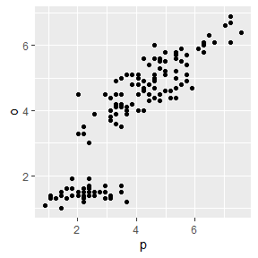

```r
opmetrics(iris$Petal.Length, predict(m), plot = TRUE)
```

This object can be used as any ggplot, so adding graphics and changing the theme.

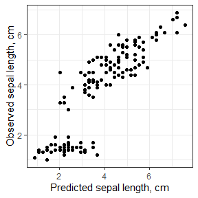

```r
opmetrics(iris$Petal.Length, predict(m), plot = TRUE) +
  labs(x = "Predicted sepal length, cm", y = "Observed sepal length, cm") +
  theme_bw()
```

If you want to plot the residuals instead just add `residuals = TRUE`. Note residuals are plotted against predicting, as it should be (St-Pierre 2003).

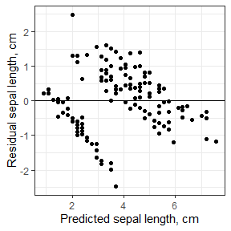

```r
opmetrics(iris$Petal.Length, predict(m), plot = TRUE, residuals = TRUE) +
  geom_hline(yintercept = 0) +
  labs(x = "Predicted sepal length, cm", y = "Residual sepal length, cm") +
  theme_bw()
```

Not a great model, maybe by adding species it could look better.

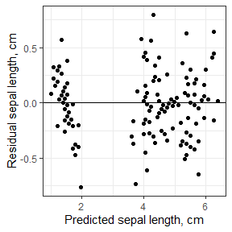

```r
m <- lm(Petal.Length ~ Sepal.Length + Species, iris)

opmetrics(iris$Petal.Length, predict(m), plot = TRUE, residuals = TRUE) +
  geom_hline(yintercept = 0) +
  labs(x = "Predicted sepal length, cm", y = "Residual sepal length, cm") +
  theme_bw()
```

### metricsloop

With `metricsloop` is possible to compare metrics fom different models beloning to the same model class, just by providing the models of interest, thanks to the loop built in the function.

```r
mods <- c("Sepal.Length",
          "Sepal.Length+Species",
          "Sepal.Length*Species")

metricsloop(d = iris, var = "Petal.Length", MT = "lm", m = mods, PF = "predict", s = "std1")
```

```
#>           N Observed Mean Predicted Mean RMSE RMSE, % mean Mean Bias, % MSE
#> Values  150          3.76           3.76 0.86        22.94           <0.001
#> Values1 150          3.76           3.76 0.28         7.42           <0.001
#> Values2 150          3.76           3.76 0.26         6.81           <0.001
#>         Slope Bias, % MSE Dispersion, % MSE Mean Bias Slope Bias
#> Values             <0.001               100    <0.001     <0.001
#> Values1            <0.001               100    <0.001     <0.001
#> Values2            <0.001               100    <0.001     <0.001
#>         Dispersion Bias P-Mean Bias P-Slope Bias  RSR  CCC  MAE MAE, % mean
#> Values             0.74           1            1 0.49 0.86 0.71       18.81
#> Values1            0.08           1            1 0.16 0.99 0.21        5.72
#> Values2            0.07           1            1 0.14 0.99  0.2        5.24
#>                  Var ModelType                Model Predict
#> Values  Petal.Length        lm         Sepal.Length predict
#> Values1 Petal.Length        lm Sepal.Length+Species predict
#> Values2 Petal.Length        lm Sepal.Length*Species predict
```

And for better table visualization via flextable, of course is also possible to print it as csv/spreadsheet.

```r
flextable(metricsloop(d = iris, var = "Petal.Length", MT = "lm", m = mods, PF = "predict", s = "std1")
) %>% autofit()
```

| N | Observed Mean | Predicted Mean | RMSE | RMSE, % mean | Mean Bias, % MSE | Slope Bias, % MSE | Dispersion, % MSE | Mean Bias | Slope Bias | Dispersion Bias | P-Mean Bias | P-Slope Bias | RSR | CCC | MAE | MAE, % mean | Var | ModelType | Model | Predict |
| --- | --- | --- | --- | --- | --- | --- | --- | --- | --- | --- | --- | --- | --- | --- | --- | --- | --- | --- | --- | --- |
| 150 | 3.76 | 3.76 | 0.86 | 22.94 | <0.001 | <0.001 | 100 | <0.001 | <0.001 | 0.74 | 1 | 1 | 0.49 | 0.86 | 0.71 | 18.81 | Petal.Length | lm | Sepal.Length | predict |
| 150 | 3.76 | 3.76 | 0.28 | 7.42 | <0.001 | <0.001 | 100 | <0.001 | <0.001 | 0.08 | 1 | 1 | 0.16 | 0.99 | 0.21 | 5.72 | Petal.Length | lm | Sepal.Length+Species | predict |
| 150 | 3.76 | 3.76 | 0.26 | 6.81 | <0.001 | <0.001 | 100 | <0.001 | <0.001 | 0.07 | 1 | 1 | 0.14 | 0.99 | 0.2 | 5.24 | Petal.Length | lm | Sepal.Length*Species | predict |

### metricsloopmix

With `metricsloopmix` is possible to compare metrics fom different models beloning to the different model classes, just by providing the models of interest, thanks to the loop built in the function.

```r
modclass <- c("lm", "glm")
modsid <- c("Sepal.Length", "Sepal.Length, family = Gamma")

modsdata <- data.frame(modclass, modsid)

metricsloopmix(d = iris, var = "Petal.Length", MO = modsdata, s = "std1")
```

```
#>           N Observed Mean Predicted Mean RMSE RMSE, % mean Mean Bias, % MSE
#> Values  150          3.76           3.76 0.86        22.94           <0.001
#> Values1 150          3.76            0.3 3.91       104.15            77.92
#>         Slope Bias, % MSE Dispersion, % MSE Mean Bias Slope Bias
#> Values             <0.001               100    <0.001     <0.001
#> Values1             17.23              4.85      3.45     <0.001
#>         Dispersion Bias P-Mean Bias P-Slope Bias  RSR    CCC  MAE MAE, % mean
#> Values             0.74           1            1 0.49   0.86 0.71       18.81
#> Values1            0.74      <0.001       <0.001 2.22 <0.001 3.45       91.93
#>                  Var ModelType                        Model
#> Values  Petal.Length        lm                 Sepal.Length
#> Values1 Petal.Length       glm Sepal.Length, family = Gamma
```

Is also possible to use different `predict functinos` by setting `PF = TRUE`, and additing a third column the the `MO` data with the prediction function intended for each model.

```r
modclass <- c("lm", "glm")
modsid <- c("Sepal.Length", "Sepal.Length, family = Gamma")
modpredict <- c("predict.lm", "predict.glm")
predictype <- c("response", "response")

modsdata <- data.frame(modclass, modsid, modpredict,predictype)

metricsloopmix(d = iris, var = "Petal.Length", MO = modsdata, PF = TRUE, s = "std1")
```

```
#>           N Observed Mean Predicted Mean RMSE RMSE, % mean Mean Bias, % MSE
#> Values  150          3.76           3.76 0.86        22.94           <0.001
#> Values1 150          3.76           3.76 1.36        36.15           <0.001
#>         Slope Bias, % MSE Dispersion, % MSE Mean Bias Slope Bias
#> Values             <0.001               100    <0.001     <0.001
#> Values1             14.57             85.43    <0.001     <0.001
#>         Dispersion Bias P-Mean Bias P-Slope Bias  RSR  CCC  MAE MAE, % mean
#> Values             0.74           1            1 0.49 0.86 0.71       18.81
#> Values1            1.58           1       <0.001 0.77  0.7 1.13       29.96
#>                  Var ModelType                        Model     Predict
#> Values  Petal.Length        lm                 Sepal.Length  predict.lm
#> Values1 Petal.Length       glm Sepal.Length, family = Gamma predict.glm
#>             Type
#> Values  response
#> Values1 response
```

And for better table visualization via flextable.

```r
flextable(metricsloopmix(d = iris, var = "Petal.Length", MO = modsdata, PF = TRUE, s = "std1")) %>% autofit()
```

| N | Observed Mean | Predicted Mean | RMSE | RMSE, % mean | Mean Bias, % MSE | Slope Bias, % MSE | Dispersion, % MSE | Mean Bias | Slope Bias | Dispersion Bias | P-Mean Bias | P-Slope Bias | RSR | CCC | MAE | MAE, % mean | Var | ModelType | Model | Predict | Type |
| --- | --- | --- | --- | --- | --- | --- | --- | --- | --- | --- | --- | --- | --- | --- | --- | --- | --- | --- | --- | --- | --- |
| 150 | 3.76 | 3.76 | 0.86 | 22.94 | <0.001 | <0.001 | 100 | <0.001 | <0.001 | 0.74 | 1 | 1 | 0.49 | 0.86 | 0.71 | 18.81 | Petal.Length | lm | Sepal.Length | predict.lm | response |
| 150 | 3.76 | 3.76 | 1.36 | 36.15 | <0.001 | 14.57 | 85.43 | <0.001 | <0.001 | 1.58 | 1 | <0.001 | 0.77 | 0.7 | 1.13 | 29.96 | Petal.Length | glm | Sepal.Length, family = Gamma | predict.glm | response |

## Metrics included

Following a list of the metrics included. Where ${Y}_i$ is the observed values, $\hat{Y}_i$ is the predicted values from the model, $n$ is the number of observations, $\mu$ is the average of the observed values, and $\sigma$ is the standard deviation of the observed values.

### Mean Square Error

Can be used as such, or to calculate the proportion of the decompose error (Bibby and Toutenburg 1977).

$$MSE =
\frac{\sum_{i=1}^{n}(Y_i-\hat{Y}_i)^2 }{n}$$

### Root Mean Square Error (RMSE)

As absolute value and as proportion of the mean observed values. Main indicator of goodness of a model (Bibby and Toutenburg 1977).

$$RMSE = \sqrt{MSE} \text{ or }
\sqrt{MSE}/\mu$$

### Mean Absolute Error (MAE)

Simular to the RMSE but with a lower weight of the residuals further from the zero (Chai and Draxler 2014). As for the RMSE it can be divided by $\mu$ to have the MAE as a proportion of the mean observed values.

$$MAE =
\frac{\sum_{i=1}^n|Y_i-{\hat{Y}_i}|}{n}$$

### Mean Bias

Expressed as percentage of MSE, and calculated as squared bias.

$$MB =
\biggr[ \frac{\sum_{i=1}^{n}(Y_i-\hat{Y}_i)}{n} \biggr]^2$$

### Random Bias (DB)

Expressed as percentage of MSE.

From the regression:

$$Y_i - \hat{Y}_i = \hat{Y}_i +
\epsilon_i$$

$$DB = \frac{\sum_{i=1}^{n}\epsilon_i^2
}{n}$$

### Slope Bias (SB)

Expressed as percentage of MSE.

$$SP = MSE - MB - DB$$

### RMSE-observations standard deviation ratio (RSR)

Calcualted as presented in Moriasi, D. N. et al. (2007).

$$RSR = RMSE/\sigma$$

### Concordance Correlation Coefficient (CCC)

Calculated according to Lin (1989) using the R package Stevenson et al. (2023).

## Alternative mean bias formulation

$$MB = \biggr[
\frac{\sum_{i=1}^{n}Y_i}{n}-\frac{\sum_{i=1}^{n}\hat{Y}_i)}{n} \biggr]
^2$$

# References

Bibby, John, and Helge Toutenburg. 1977. *Prediction and Improved Estimation in Linear Models*. Wiley.

Chai, T., and R. R. Draxler. 2014. “Root Mean Square Error (RMSE) or Mean Absolute Error (MAE)? Arguments Against Avoiding RMSE in the Literature.” *Geoscientific Model Development* 7 (3): 1247–50. https://doi.org/10.5194/gmd-7-1247-2014.

Lin, Lawrence I-Kuei. 1989. “A Concordance Correlation Coefficient to Evaluate Reproducibility.” *Biometrics* 45 (1): 255–68. https://doi.org/10.2307/2532051.

Moriasi, D. N., Arnold, J. G., Van Liew, M. W., Bingner, R. L., Harmel, R. D., and Veith, T. L. 2007. “Model Evaluation Guidelines for Systematic Quantification of Accuracy in Watershed Simulations.” *Transactions of the ASABE* 50 (3): 885–900. https://doi.org/10.13031/2013.23153.

Piñeiro, Gervasio, Susana Perelman, Juan P. Guerschman, and José M. Paruelo. 2008. “How to Evaluate Models: Observed Vs. Predicted or Predicted Vs. Observed?” *Ecological Modelling* 216 (3): 316–22. https://doi.org/10.1016/j.ecolmodel.2008.05.006.

Stevenson, Mark, Evan Sergeant, Cord Heuer, Telmo Nunes, Cord Heuer, Jonathon Marshall, Javier Sanchez, et al. 2023. “epiR: Tools for the Analysis of Epidemiological Data.”

St-Pierre, N. R. 2003. “Reassessment of Biases in Predicted Nitrogen Flows to the Duodenum by NRC 2001.” *Journal of Dairy Science* 86 (1): 344–50. https://doi.org/10.3168/jds.S0022-0302(03)73612-1.